# Tutorial of Boolean Network Analysis of Time Series Data

Written by Xiao Yang

last updated Aug, 2023

## Overview

Dynamical system methods have been instrumental in explaining mechanisms of change and predicting future trajectories and states of psychological systems (Boker & Graham, 1998; Chow, Ferrer, & Hsieh, 2010). A natural next step is to use these methods to design control strategies and guide system trajectories (Molenaar & Nesselroade, 2015; Wang et al., 2014).

In this tutorial, we introduce and forward a Boolean network method because it can give an intuitive explanation of psychological dynamics that are useful for theorists and suggestions for network control that are useful for practitioners. We demonstrate the utility of the Boolean network through analysis of multivariate binary time-series data simulated to mimic intensive longitudinal data (e.g., ecological momentary assessment).

## Boolean network

Boolean network (Kauffman, 1969, 1993) method is a specific instantiation of discrete dynamical system model. The special characteristic of the Boolean network method is to use the Boolean operators, including **AND (&)**, **OR (|)**, or **NOT (!)**, to describe and model temporal dynamics between variables.

The Boolean network method is like a vector-autoregression (VAR) model, whereas the temporal relations are expressed using the Boolean operators, and the variables are binary.

**Data type that can use the Boolean network method:** The Boolean netowrk method can be applied on intensive longitudinal data (e.g., Ecological Momentary Assessment, physiological data, physical activity) to model the temporal dynamics and facilitate control design. The method can work on binary time-series, and continuous-scale time-series, which need to be binarized (see Step 0).

We are using the R package *BoolNet* (Mussel et al., 2010) to conduct the data analysis in this tutorial.

This tutorial is to demonstrate the following 6 steps of Boolean network approach, including:

0. Binarization of continuous data
1. Simulation of binary data
2. Inference of Boolean functions
3. Plotting state space transition graph
4. Extraction of attractors
5. Design of network control

```r
library(ggplot2) # for data visualization
library(BoolNet) # for Boolean network modeling
library(dplyr) # for data organization
library(igraph) # for network plotting
library(stringdist) # for computing distance between strings/sequences
library(stringr) # for computing distance between strings/sequences
library(reshape2) # for data organization
library(metafolio) # for color specification

set.seed(12345)
```

## Step 0: Binarization of continuous data

Binarization is to convert the continuous-scale variables to binary variables, so that it can be fitted into the Boolean model. This is done using the *“binarizeTimeSeries”* function in BoolNet package, and note here the binarization is done by rows, instead of by columns. Since we usually use the long-format to organize intensive longitudinal data, we take the transpose here to transform the data into a format that each row is a variable.

The *“binarizeTimeSeries”* function is using k-means clustering and k (number of groups) = 2.

Here we show an example of how binarization works on continuous-scale data. You can plug in your continuous-scale data in this step, to get binarized data.

```r
n.obs <- 20 # set the length of the time-series

# simulate a 3-variate continuous-scale time-series using a uniform distribution between 0 and 1.
continuous.time.series <- cbind(runif(n.obs,0, 1),
                     runif(n.obs,0, 1),
                     runif(n.obs,0, 1))
```

#### If you have continuous-scale time-series data, start with this step to convert your data

```r
# transpose to wide-format
continuous.time.series <- t(continuous.time.series)

# check to see the continuous-scale
print(continuous.time.series[,1:5]) # print the first 5 columns in the binarized data
```

```
##           [,1]      [,2]      [,3]      [,4]      [,5]
## [1,] 0.7209039 0.8757732 0.7609823 0.8861246 0.4564810
## [2,] 0.4537281 0.3267524 0.9654153 0.7074819 0.6445426
## [3,] 0.7821933 0.4291988 0.9272740 0.7732432 0.2596812
```

```r
# binarize the continuous-scale variables
bin.continuous.time.series <- binarizeTimeSeries(continuous.time.series)

# show the threshold of the 3 variables
bin.continuous.time.series$thresholds
```

```
## [1] 0.5600568 0.5183026 0.5204997
```

```r
# print the first five time points
print(bin.continuous.time.series$binarizedMeasurements[,1:5]) # print the first 5 columns in the binarized data
```

```
##      [,1] [,2] [,3] [,4] [,5]
## [1,]    1    1    1    1    0
## [2,]    0    0    1    1    1
## [3,]    1    0    1    1    0
```

Here, we can see the function “binarizeTimeSeries” split the continuous-scale data into two groups using the threshold, e.g., any value that is above 0.5600568 in the first variable (first row) will be converted to 1, otherwise it will be converted to 0.

## Step 1: Simulation of binary time-series data

### Why simulate?

This step is to generate a binary-scale multivariate time-series which allow us to look at how the model works without empirical data. It has the advantage that we know what is the underlying temporal dynamics with the simulated data, and examine how the method recovered the temporal dynamics in estimates.

### How is the data simulated?

Data are simulated for a 3-node network. Time series was simulated based on the temporal relations and process noise. Our hypohetical 3-node newtork was using simulated data based on a pre-defined Boolean functions and process noise. The Boolean functions are expressed in the following equations:

x1(t+1) = x3(t)

x2(t+1) = x1(t) OR x3(t)

x3(t+1) = NOT x1(t) AND x2(t)

The process noise is to flip the binary variable at each time step with a probability of 0.05.

The three-node network is a hypothetical example used for the purpose of illustration. The Boolean functions and noise probability were arbitrarily chosen.

We simulate 20 steps to generate a relatively short time-series.

```r
p <- 3 # number of variables

# randomly generated number for each time-step, so that the noise can be added
zeta <- cbind(runif(n.obs,0, 1),
              runif(n.obs,0, 1),
              runif(n.obs,0, 1)) # 3 time-series of noise for 3 variables
zeta <- t(zeta) # adjust zeta to a wide-format

time.series <- matrix(rep(0, p * n.obs), nrow =p , ncol =  n.obs)
time.series[,1] <- runif(p,0, 1) # initial value of the three variables were randomly chosen
chance.to.flip <- 0.05 # probability of adding noise at each time step

time.series[,1] <-ifelse(time.series[,1] >= .5, TRUE,FALSE)

for (col in 2:n.obs)
{
  # simulate each time step based on the previous time step and Boolean functions
  time.series[1,col] <- time.series[3,col-1]  # x1 = x3
  time.series[2,col] <- time.series[1,col-1] | time.series[3,col-1] # x2 = x1 OR x3
  time.series[3,col] <- !time.series[1,col-1] & time.series[2, col -1] # x3 = NOT x1 AND x2

  # add noise, if the random number in zeta is less than 0.05, then taking the opposite value
  time.series[1,col] <- ifelse(zeta[1,col] < chance.to.flip,
                                               !time.series[1,col],
                                               time.series[1,col] )
  time.series[2,col] <- ifelse(zeta[2,col] < chance.to.flip,
                                               !time.series[2,col],
                                               time.series[2,col] )
  time.series[3,col] <- ifelse(zeta[3,col] < chance.to.flip,
                                               !time.series[3,col],
                                               time.series[3,col] )
}

# adjust the time-series to long-format
time.series <- t(time.series)
time.series <- data.frame(time.series)
names(time.series) <- c("x1", "x2", "x3")
```

#### Plot the binary time-series

Here we plot the converted time-series, and now it is in the binary format. Any colored area indicates the variable is 1, and white area indicates the variable is 0.

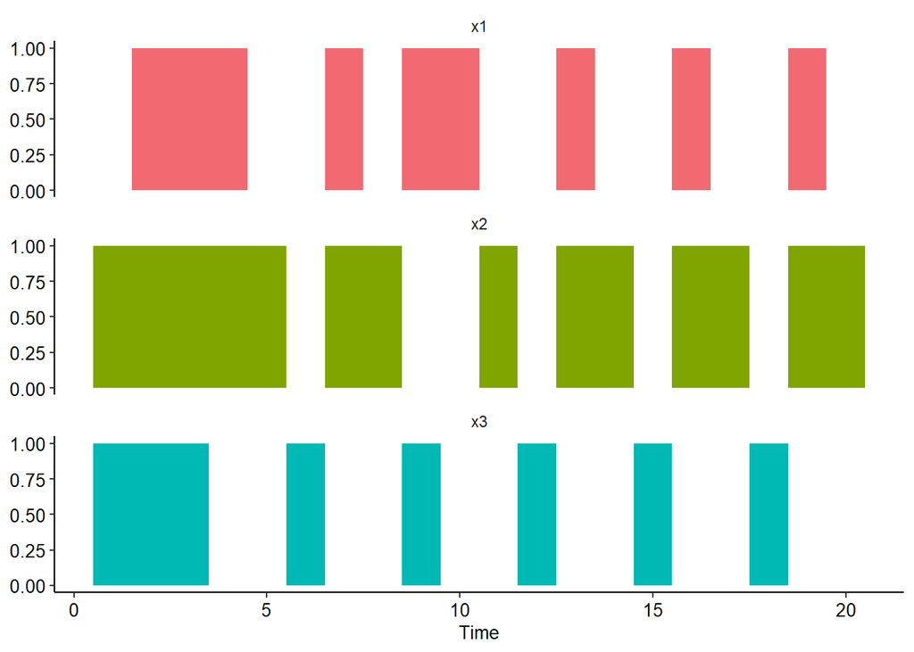

```r
# specify the colors of the time-series
n <- ncol(time.series)
cols <- gg_color_hue(n)

# for plotting purposes, convert the binary time-series back to long-format
bin.data.plot <- time.series
bin.data.plot <- data.frame(bin.data.plot)
bin.data.plot$index <- 1:nrow(bin.data.plot)

bin.data.plot.melt <- melt(bin.data.plot,id = "index")

bin.data.plot.melt$value.variable <- ifelse(bin.data.plot.melt$value==0,"0",                                        as.character(bin.data.plot.melt$variable))

bin.data.plot.melt$value.variable <- factor(bin.data.plot.melt$value.variable,
                                            levels = c("0","x1",
                                                       "x2",
                                                       "x3"))

ggplot(data = bin.data.plot.melt)+
        geom_rect(aes(xmin = index - .5, xmax = index + .5,
                      ymin = 0, ymax = 1, fill = factor( value.variable)))+
  facet_wrap(~variable, ncol = 1) +
  scale_fill_manual(values = c("#FFFFFF", cols))+
  theme(
    strip.background = element_blank(),
    panel.background = element_blank(),
    legend.title =   element_blank(),
    legend.key = element_blank(),
    legend.position = "none",
    axis.text.y=element_text(color="black",size=10),
    axis.text.x=element_text(color="black",size=10),
    axis.title.y=element_text(color="black",size=10),
    axis.title.x=element_text(color="black",size=10),
    axis.line = element_line(color = 'black'))+
  ylim(0,1)+
  xlab("Time")
```

## Step 2: Inference of Boolean functions

```r
net.data <- t(time.series)
network.size<- p

booleannet <- reconstructNetwork(net.data,
                          method = "bestfit",
                          maxK = 2,
                          readableFunctions=T,
                          returnPBN = F)
print(booleannet)
```

```
## Probabilistic Boolean network with 3 genes
##
## Involved genes:
## x1 x2 x3
##
## Transition functions:
##
## Alternative transition functions for gene x1:
## x1 = (x3) (error: 1)
##
## Alternative transition functions for gene x2:
## x2 = (x3) | (x1) (error: 1)
##
## Alternative transition functions for gene x3:
## x3 = (!x1 & x2) (error: 1)
```

```r
# saveNetwork(net, paste(outputpath, id,"-network.txt", sep = "")) # can't save a collection of BN
```

We can see the Boolean functions we simulated the data from are recovered here by the inference, which are:

x1(t+1) = x3(t)

x2(t+1) = x1(t) OR x3(t)

x3(t+1) = NOT x1(t) AND x2(t)

Note that this is only to showcase how the Boolean network inference works, future work can execute a comprehensive simulation study, which requires robust testing of multiple factors, including a variety of forms of Boolean funtions, observation length, noise.

### How Boolean functions are inferred?

The details of how the Boolean functions are inferred can be found in Akutsu et al. (2000). The essence of the inference is to compare the outcome varible’s time-series at time t+1 and the time-series of the input variables at time t, after appyling the Boolean operator AND, OR, or NOT; and find which predictors and Boolean operators are the closest match of the outcome variable.

### What is error?

Error here is the sum of false negative (predicting the outcome as 0 when it was actually 1) and false positive (predicting the outcome as 1 when it was actually 0). Note the total number of time points is 20 in the simulated time-series, and error = 1 indicates out of 20 time points 1 was predicted incorrectly using the “bestfit” algorithm.

### How to interpret the Boolean functions?

Take function x2 = (x1 | x3) as an example:

This indicates x2(t+1) is predicted by x1(t) **OR** x3(t), which means only when either x1(t) or x3(t) are 1, x2(t+1) is 1; otherwise, x2(t+1) will be 0. **OR** rule is similar to an additive rule, so whenever there is a 1 in an OR rule, the outcome will be 1.

Another way to talk about the interpretation of this Boolean function is x2 will be turned ON at time t+1 when either x1 or x3 was turned ON at time t.

### What are the possible applications in psychology?

In psychology, when two variables have to work together to activate another variable, it is an AND rule, e.g., when both group member A and group member B are self-disclosing, group member B will continue to self-disclose the next time (maybe member B needed to feel supported from member A). A Boolean function that looks like B(t+1) = A(t) & B(t) describes such a dynamic.

Here, we select the fisrt network if more than 1 rule inferred per node, so that the attractors can be extracted.

```r
# note here we only chose the first function of all possible functions
singlenet <- chooseNetwork(booleannet,
            functionIndices = rep(1,network.size),
            dontCareValues=rep(1,network.size),
            readableFunctions=T)
print(singlenet)
```

```
## Boolean network with 3 genes
##
## Involved genes:
## x1 x2 x3
##
## Transition functions:
## x1 = (x3)
## x2 = (x3) | (x1)
## x3 = (!x1 & x2)
```

### Why extract attractors first?

Note here, we extract attractors first (Step 4) because state transition graph needs the attractor object as an input. But we will explain what the attractors mean later, as the state transition graph (Step 3) will help you understand the concept of attractor.

```r
ga <- getAttractors(network = singlenet,
                  returnTable = TRUE)

# print(ga, activeOnly=TRUE)
```

# Step 3: Plot state space transition graph

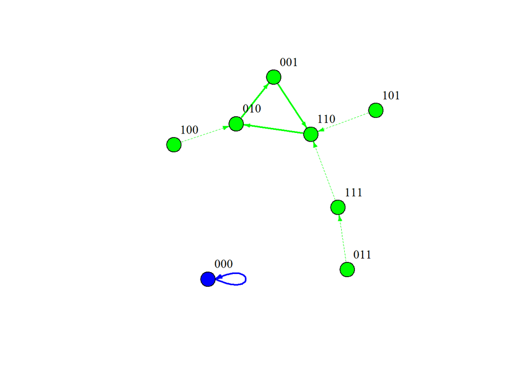

```r
p<-plotStateGraph(ga,
               piecewise=TRUE,
               drawLabels = T,
               plotIt = F,
               colorsAlpha = c(colorBasinsNodeAlpha    = 1,
                               colorBasinsEdgeAlpha    = 1,
                               colorAttractorNodeAlpha = 1,
                               colorAttractorEdgeAlpha = 1))
plot.igraph(p,
            label.cex = 1.2,
            vertex.label.color="black",
            vertex.label.dist=3,
            remove.loops = T,
            edge.arrow.size=.4)
```

### What is an attractor and how can I tell from the state transition graph?

When a state transitions back to itself, it is an attractor - as the system gravitates toward an attractor. Here in each attractor, there is 1 or multiple attractor state(s) that the system tends to stay for a long run.

# Step 4: Extraction of attractors

```r
print(ga, activeOnly=TRUE)
```

```
## Attractor 1 is a simple attractor consisting of 1 state(s) and has a basin of 1 state(s).
## Active genes in the attractor state(s):
## State 1: --
##
## Attractor 2 is a simple attractor consisting of 3 state(s) and has a basin of 7 state(s).
## Active genes in the attractor state(s):
## State 1: x2
## State 2: x3
## State 3: x1, x2
```